# Notebook

[Sebastian Raschka](http://sebastianraschka.com)

- [Open in IPython nbviewer](http://nbviewer.ipython.org/github/rasbt/One-Python-benchmark-per-day/blob/master/ipython_nbs/day11_deque_container.ipynb?create=1)
- [Link to this IPython notebook on Github](https://github.com/rasbt/One-Python-benchmark-per-day/blob/master/ipython_nbs/day11_deque_container.ipynb)
- [Link to the GitHub Repository One-Python-benchmark-per-day](https://github.com/rasbt/One-Python-benchmark-per-day)

```python
import time
print('Last updated: %s' %time.strftime('%d/%m/%Y'))
```

```
Last updated: 17/06/2014
```

I am really looking forward to your comments and suggestions to improve and  
extend this little collection! Just send me a quick note  
via Twitter: [@rasbt](https://twitter.com/rasbt)  
or Email:

# Day 11 - One Python Benchmark per Day

## The `deque` container data type

The `collections` module in Python's standard library provides some convienient container datatypes that not only make your code more "Pythonic", but they also are optimized for performance for certain operations. Previously, we have seen how we can use the `collections.Counter` class ([Day 3: 6 different ways for counting elements using a dictionary](http://nbviewer.ipython.org/github/rasbt/One-Python-benchmark-per-day/blob/master/ipython_nbs/day3_dictionary_counting.ipynb?create=1)) to write short and efficient code to quantify items.  
Today, we will take a look at another `collections` class: the [`deque`](https://docs.python.org/2/library/collections.html#collections.deque) container data type.

### Sections

- A short introduction to deques
- Benchmarking via timeit
- Results
- Conclusion

## A short introduction to deques

Most of you might already be familiar with `deque`s due to their popularity in C++ and might want to skip this short introduction.

For all the others: `deque` (pronounced "deck") is short for "double-ended queue" and thus it is sometimes also written as "dequeue". This abstract data structure is quite similar to an array (or Python list), which is optimized for adding and removing elements from either the back or front.  
The `deque` class comes with methods that are already familiar from the Python `list` type, such as

### Common methods for Python's `list` and `deque` objects

- `append(val)`  
  appends and element to the right
- `clear()`  
  removes all elements
- `count(val)` returns the number of elements that are equal to `val`
- `extend(iterable)`  
  adds elements to the right from an iterable object
- `pop()`  
  removes and returns an element from the right end
- `reverse()`  
  reverses elements in-place; returns `None`
- `remove(val)`  
  removes first occurence of `val`

### Methods unique to `deque` objects

- `appendleft(val)`  
  appends an element to the left
- `extendleft(iterable)`  
  adds elements to the left from an iterable object
- `popleft()`  
  removes and returns an element from the left end
- `rotate(n)`  
  Rotate the deque n steps to the right. If n is negative, rotate to the left. Rotating one step to the right is equivalent to: d.appendleft(d.pop()).

```python
import collections
a = collections.deque([1,2,3])
a.rotate(2)
print(a)
```

```
deque([2, 3, 1])
```

Note that `deque`s don't have equivalents to the Python `list` methods, such as `index()` for looking up values, or the `.sort()` method (although the `sorted()` function can be used as a workaround). If we want to get a slice from a `deque`, equivalent to `my_list[0:3]`, we would need to use `itertools`, for example.

```
import itertools
list(itertools.islice(my_deque, 0, 3))
```

# Benchmarking via timeit

[back to top]

```python
import timeit
import collections
from copy import copy



labels = ['.append()', '.insert(0,x)\n.appendleft(x)',
          '.pop()', '.pop(0)\n.popleft()', '.reverse()']
list_time, deque_time = [], []

n = 10000
l = [i for i in range(n)]
d = collections.deque([i for i in range(n)])

l_cp, d_cp = copy(l), copy(d)
list_time.append(min(timeit.Timer('l_cp.append(1)',
            'from __main__ import l_cp').repeat(repeat=3, number=1000)))
deque_time.append(min(timeit.Timer('d_cp.append(1)',
            'from __main__ import d_cp').repeat(repeat=3, number=1000)))

l_cp, d_cp = copy(l), copy(d)
list_time.append(min(timeit.Timer('l_cp.insert(0,1)',
            'from __main__ import l_cp').repeat(repeat=3, number=1000)))
deque_time.append(min(timeit.Timer('d_cp.appendleft(1)',
            'from __main__ import d_cp').repeat(repeat=3, number=1000)))

l_cp, d_cp = copy(l), copy(d)
list_time.append(min(timeit.Timer('l_cp.pop()',
            'from __main__ import l_cp').repeat(repeat=3, number=1000)))
deque_time.append(min(timeit.Timer('d_cp.pop()',
            'from __main__ import d_cp').repeat(repeat=3, number=1000)))

l_cp, d_cp = copy(l), copy(d)
list_time.append(min(timeit.Timer('l_cp.pop(0)',
            'from __main__ import l_cp').repeat(repeat=3, number=1000)))
deque_time.append(min(timeit.Timer('d_cp.popleft()',
            'from __main__ import d_cp').repeat(repeat=3, number=1000)))

l_cp, d_cp = copy(l), copy(d)
list_time.append(min(timeit.Timer('l_cp.reverse()',
            'from __main__ import l_cp').repeat(repeat=3, number=1000)))
deque_time.append(min(timeit.Timer('d_cp.reverse()',
            'from __main__ import d_cp').repeat(repeat=3, number=1000)))
```

## Preparing to plot the results

[back to top]

```python
import platform
import multiprocessing

def print_sysinfo():

    print('\nPython version  :', platform.python_version())
    print('compiler        :', platform.python_compiler())

    print('\nsystem     :', platform.system())
    print('release    :', platform.release())
    print('machine    :', platform.machine())
    print('processor  :', platform.processor())
    print('CPU count  :', multiprocessing.cpu_count())
    print('interpreter:', platform.architecture()[0])
    print('\n\n')
```

```python
%matplotlib inline
```

```python
import matplotlib.pyplot as plt

def plot():
    plt.rcParams.update({'font.size': 12})

    fig = plt.figure(figsize=(11,13))

    # Setting the positions and width for the bars
    pos = list(range(len(list_time)))
    width = 0.2

    # Plotting the bars
    fig, ax = plt.subplots(figsize=(8,6))

    plt.bar(pos, list_time, width,
                 alpha=0.5,
                 color='g',
                 label=labels[0])

    plt.bar([p + width for p in pos], deque_time, width,
                 alpha=0.5,
                 color='b',
                 label=labels[1])

    # Setting axis labels and ticks
    ax.set_ylabel('time in seconds\n(for 1,000 operations on starting size 10,000)')
    ax.set_title('Python list and collections.deque operations')
    ax.set_xticks([p + 1.5 * width for p in pos])
    ax.set_xticklabels(labels)

    # Setting the x-axis and y-axis limits
    plt.xlim(0-width, len(list_time))
    plt.ylim([0, max(list_time + deque_time) * 1.5])

    # Adding the legend and showing the plot
    plt.legend(['list', 'collections.deque'], loc='upper left')
    plt.grid()
    plt.show()
```

# Results

[back to top]

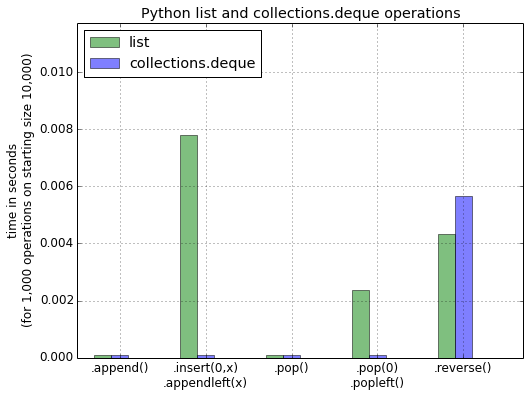

```
Python version  : 3.4.1
compiler        : GCC 4.2.1 (Apple Inc. build 5577)

system     : Darwin
release    : 13.2.0
machine    : x86_64
processor  : i386
CPU count  : 4
interpreter: 64bit
```

```python
plot()
print_sysinfo()
```

## Conclusion

[back to top]

As we can see in the plot above, the performance of the shared methods between Python `list` and `deque` objects are about the same. However, as expected, the `appendleft(x)` and `popleft(x)` methods on deques are significantly faster than workaround-approaches on Python `list`s.  
Thus, if our application requires a lot of adding and removing of items at both ends of the data structure, `deque`s are definitely to be preferred over `list`s.